# Class-Specific Booking Horizons Under Oversubscribed FCFS Scheduling

## Balking Interaction with Booking Horizons

### Balking Threshold

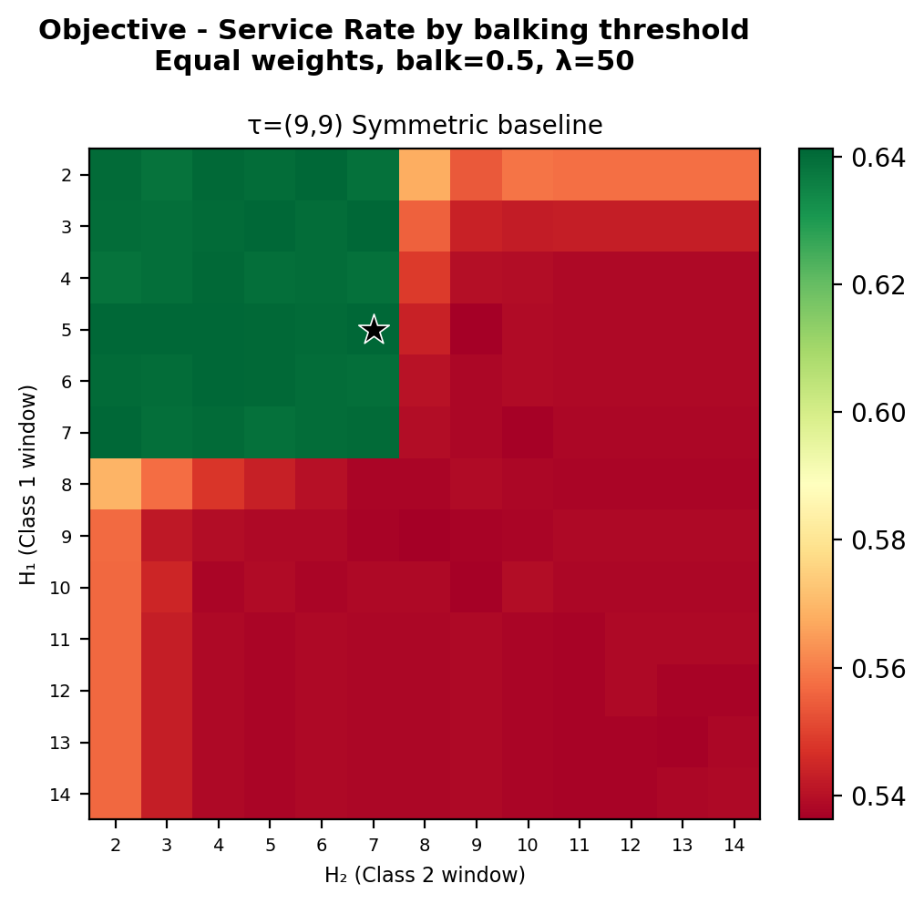

Symmetric baseline

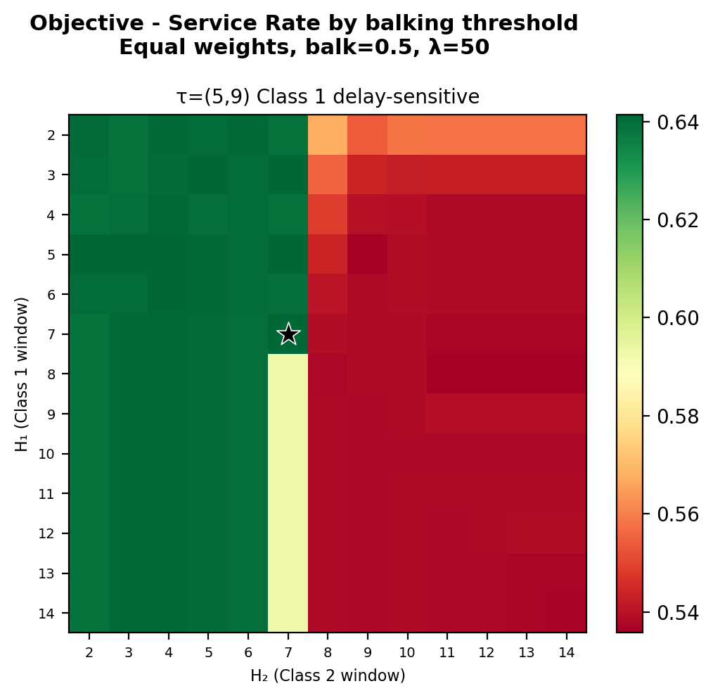

Class 1 delay-sensitive

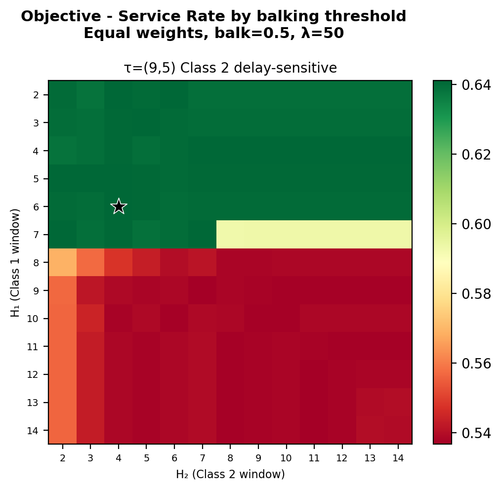

Class 2 delay-sensitive

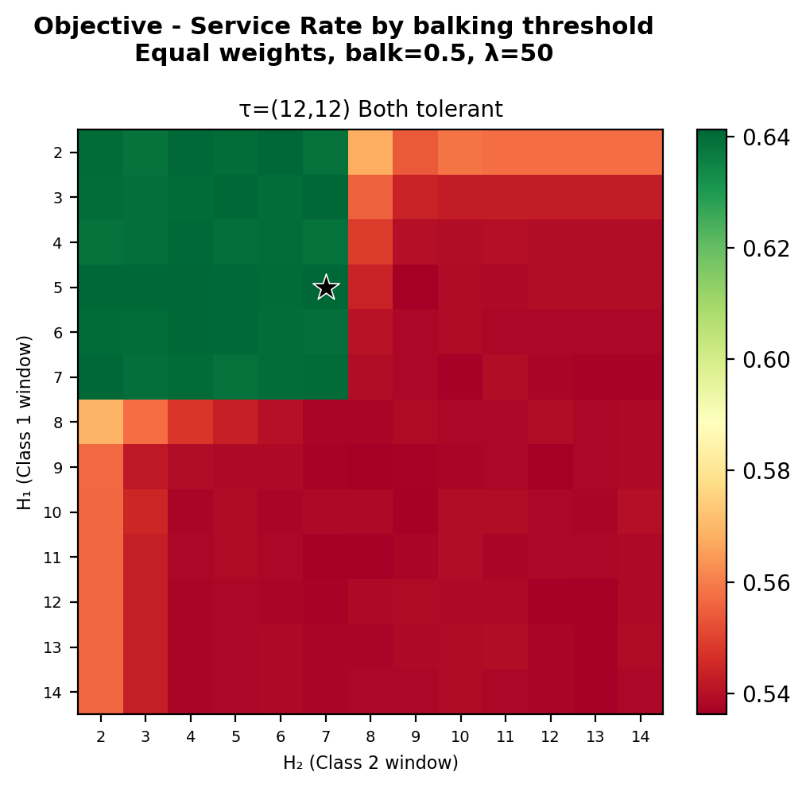

Both classes tolerant

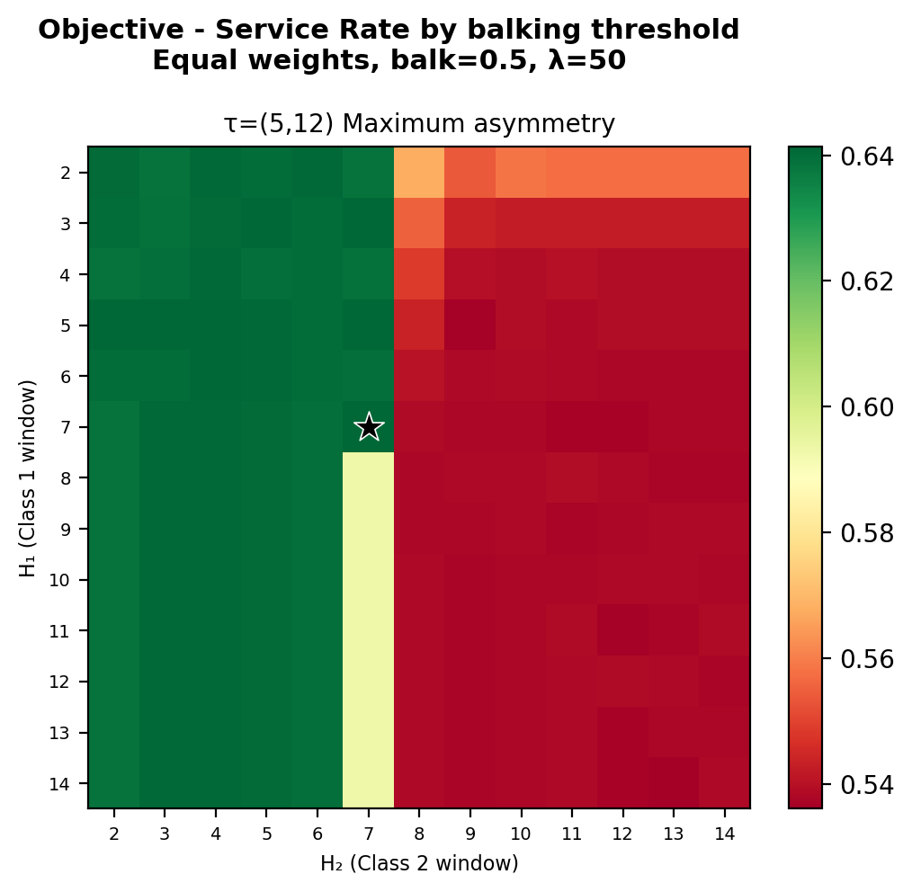

Maximum threshold asymmetry

With symmetric or tolerant balking thresholds, the high-objective region is concentrated where both horizons are seven days or shorter.

When one class has the lower threshold of 5 days, the near-optimal region extends along that class’s horizon axis to 14 days, while the competing class’s horizon remains at seven days or shorter. The lower threshold causes more patients to reject long-delay offers before those offers become bookings. Consequently, a longer nominal horizon for that class does not create the same number of long-delay booked appointments that would otherwise be exposed to elevated no-show risk.

### Class 1 Weight Counterbalance

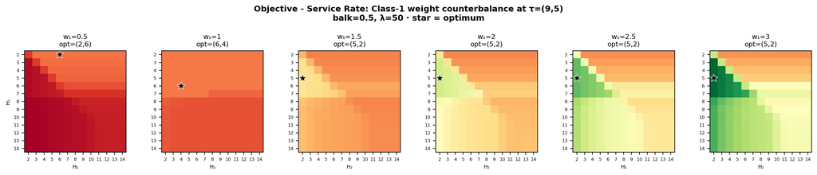

Counterbalance at tau = (9, 5)

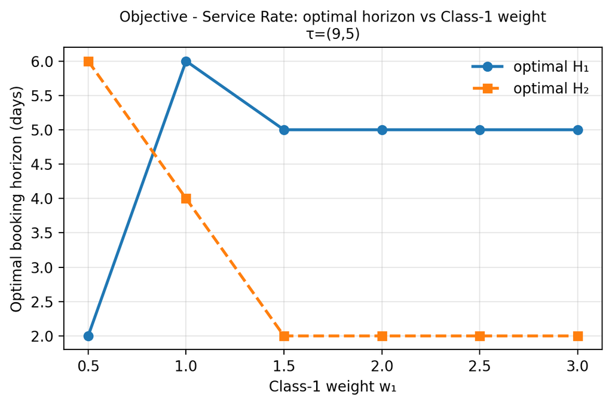

Optimal horizon versus Class 1 weight

For the threshold configuration $\tau=(9,5)$, the extended Class 2 horizon is counterbalanced by increasing the weight assigned to Class 1.

The optimal Class 2 horizon falls from 4 days when $w_1=1$ to 2 days when $w_1=1.5$, and it remains at 2 days for larger Class 1 weights. Thus, a Class 1 weight of approximately 1.5 is sufficient to return the Class 2 horizon to its minimum.

### Balking Rate

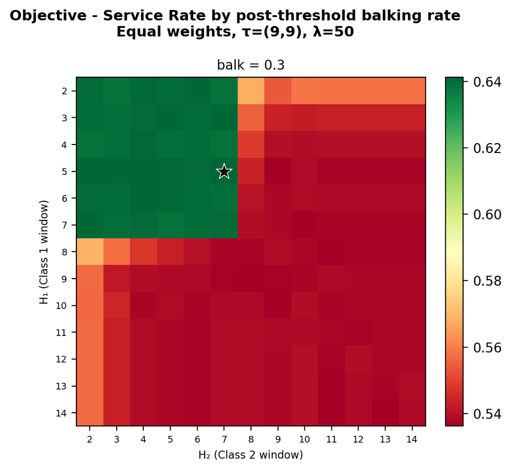

Post-threshold balking probability 0.3

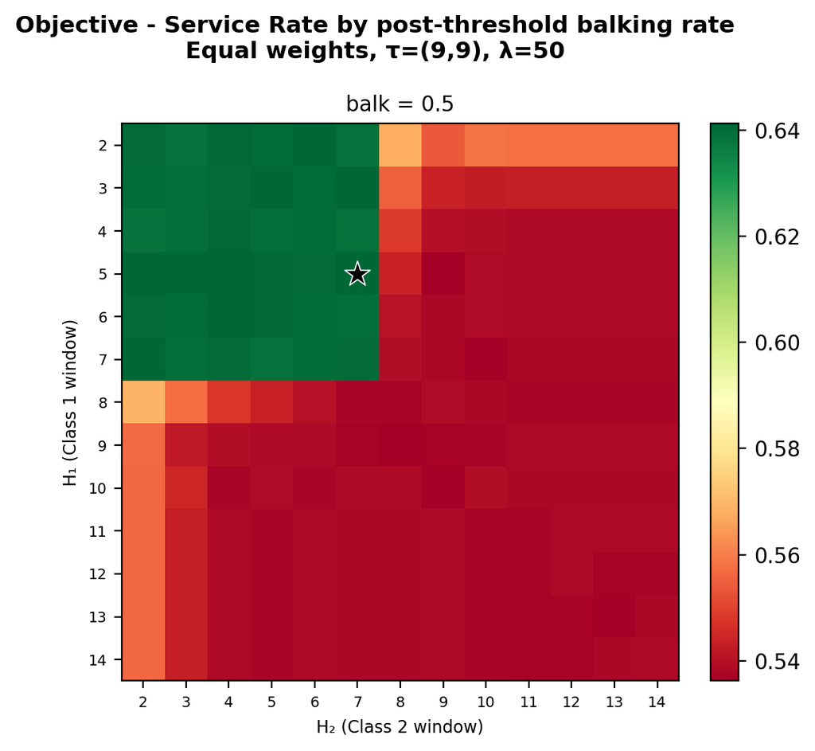

Post-threshold balking probability 0.5

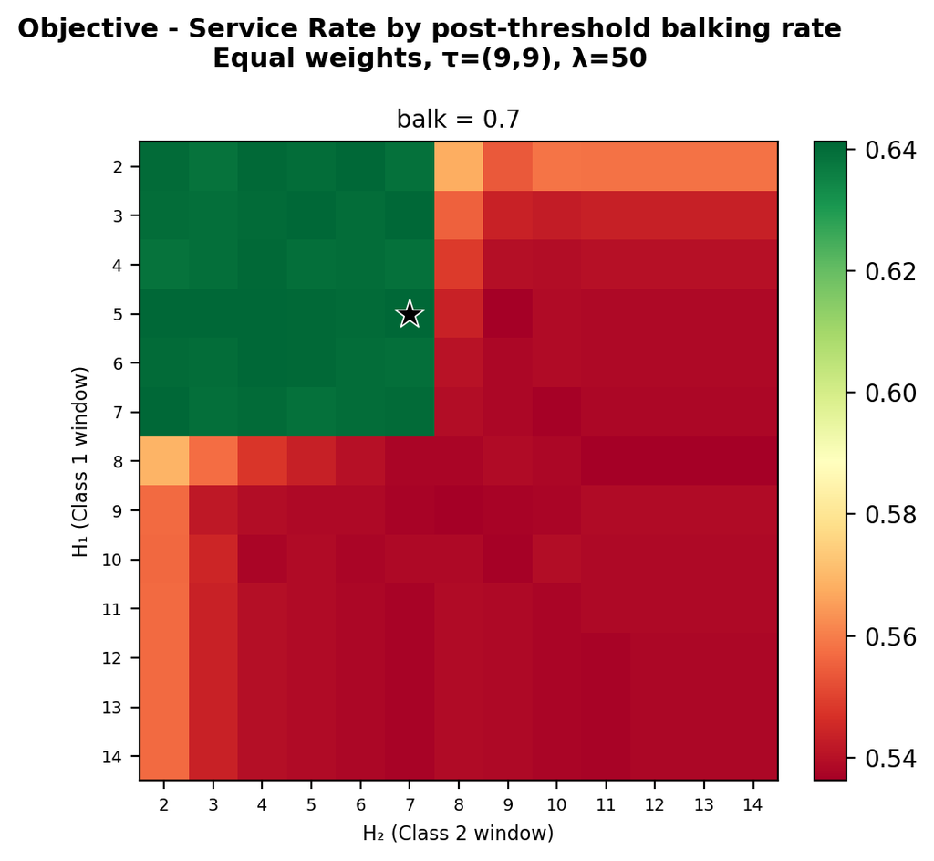

Post-threshold balking probability 0.7

Varying the common post-threshold balking probability from 0.3 to 0.7 does not meaningfully change the objective surface or the preferred horizon region. Under heavy oversubscription, capacity rejected by one balking patient can generally be taken by another arrival.